# Bioestadística, Zootecnia

Clase 8: Teorema de Bayes

Departamento de Estadı́stica, Sede Bogotá

## Clase 8

## Contenido

### Teorema de Bayes

- Problema inverso.
- Derivación paso a paso.
- Ley de probabilidad total.
- Probabilidades a priori y a posteriori.

### Aplicaciones

- Terminología bayesiana.
- Árboles de probabilidad.
- Pruebas diagnósticas.
- Ejercicios de interpretación.

## La clase anterior…

**Prob. Condicional**  
$P(A \mid B) = \dfrac{P(A \cap B)}{P(B)}$  
*Reduce el espacio muestral*

**Regla Multiplicación**  
$P(A \cap B) = P(A\mid B)\cdot P(B)$  
*Eventos secuenciales*

**Independencia**  
$P(A \cap B) = P(A)\cdot P(B)$  
*Sin influencia mutua*

**Prob. Total**  
$P(A) = \sum_i P(A\mid B_i)P(B_i)$  
*Combinar particiones*

Teorema de Bayes

Del resultado a la causa: razonamiento probabilístico inverso

Bioestadística Fundamental, Departamento de Estadística, UNAL Bogotá

## El problema inverso

- En probabilidad clásica preguntamos: **dada una causa, ¿cuál es la probabilidad del efecto?**
- Por ejemplo: si un animal *es resistente* a una enfermedad, ¿cuál es la probabilidad de que la prueba de campo lo detecte?
- Sin embargo, en la práctica con frecuencia **observamos el efecto** y necesitamos inferir la causa más probable.
- Esta lógica **de efecto a causa** se denomina el *problema inverso*.
- El **Teorema de Bayes** proporciona la herramienta matemática exacta para resolverlo.
- Permite actualizar nuestras creencias sobre una hipótesis a la luz de nueva evidencia observada.

## Motivación: una prueba diagnóstica positiva

**Escenario:** En un hato bovino en el Huila, se aplica una prueba rápida para detectar la mastitis (*Hemileia vastatrix*). El resultado es **positivo**.

- La pregunta que surge de inmediato: **¿el animal realmente tiene mastitis?**
- Sabemos que ninguna prueba es perfecta: existe la posibilidad de *falsos positivos* y *falsos negativos*.
- La respuesta depende de tres factores: la **sensibilidad** de la prueba, su **especificidad** y la **prevalencia** de la enfermedad en la zona.
- El Teorema de Bayes integra estos tres factores en un único cálculo coherente.

## Thomas Bayes (Contexto histórico)

- **Thomas Bayes** (1702–1761) fue un ministro presbiteriano y matemático inglés.
- Su ensayo *“An Essay towards Solving a Problem in the Doctrine of Chances”* fue publicado póstumamente en 1763 por Richard Price.
- Bayes planteó el problema de la inferencia inversa: actualizar probabilidades a partir de evidencia.
- Pierre-Simon Laplace formalizó y generalizó el resultado en el siglo XIX, dándole su forma actual.
- Hoy el **enfoque bayesiano** es una de las dos grandes corrientes de la estadística moderna, junto con la estadística frecuentista.
- Sus aplicaciones van desde diagnóstico médico hasta inteligencia artificial y modelos de cambio climático.

## Punto de partida: probabilidad Condicional

**Definición:** La probabilidad condicional de A dado B es:
$$P(A \mid B) = \frac{P(A \cap B)}{P(B)}, \quad P(B) > 0$$

- De modo simétrico:

  $$P(B \mid A) = \dfrac{P(A \cap B)}{P(A)}$$
- Despejando $P(A \cap B)$ de ambas expresiones obtenemos la **regla de la multiplicación**:

  $$P(A \cap B) = P(A \mid B)\,P(B) = P(B \mid A)\,P(A)$$
- Esta igualdad es el *núcleo algebraico* del Teorema de Bayes.

## Derivación del Teorema de Bayes

De la regla de multiplicación tenemos que:
$$P(A \cap B_i) = P(A \mid B_i)\,P(B_i) = P(B_i \mid A)\,P(A)$$

- Despejando $P(B_i \mid A)$:

  $$P(B_i \mid A) = \frac{P(A \mid B_i)\,P(B_i)}{P(A)}$$
- Sustituimos $P(A)$ usando la **ley de probabilidad total**:
  $$P(A) = \sum_{j=1}^{k} P(A \mid B_j)\,P(B_j)$$
- Obtenemos así la **forma completa** del Teorema de Bayes.

## Sustitución con la Ley de Probabilidad Total

$$\boxed{P(B_i \mid A) = \frac{P(A \mid B_i)\,P(B_i)}{\displaystyle\sum_{j=1}^{k} P(A \mid B_j)\,P(B_j)}}$$

- El **numerador** cuantifica cuánto contribuye la hipótesis $B_i$ a la ocurrencia del evento $A$.
- El **denominador** normaliza: garantiza que la suma de todas las probabilidades a posteriori sea 1.
- La fórmula es válida para cualquier partición $\{B_1, \ldots, B_k\}$ del espacio muestral.

## El Teorema de Bayes:

Sea $\{B_1, B_2, \ldots, B_k\}$ una partición del espacio muestral $\Omega$ con $P(B_i) > 0$ para todo $i$. Sea $A$ un evento con $P(A) > 0$. Entonces, para cada $i = 1, 2, \ldots, k$:

$$P(B_i \mid A) = \frac{P(A \mid B_i)\,P(B_i)}{\sum_{j=1}^{k} P(A \mid B_j)\,P(B_j)}$$

- Las hipótesis $B_1, \ldots, B_k$ son **mutuamente excluyentes y exhaustivas**.
- El evento $A$ es la **evidencia observada** que actualiza la probabilidad de cada hipótesis.

## Terminología Bayesiana

**Probabilidad a priori**: $P(B_i)$ probabilidad de la hipótesis *antes* de observar la evidencia. Representa el conocimiento previo.

**Verosimilitud**: $P(A \mid B_i)$ probabilidad de observar la evidencia $A$ *si* la hipótesis $B_i$ es verdadera.

**Probabilidad a posteriori**: $P(B_i \mid A)$ probabilidad de la hipótesis *después* de observar la videncia. Es la cantidad que calculamos con Bayes.

**Evidencia marginal**: $P(A)$ constante de normalización que garantiza que las probabilidades sumen 1.

## Suma de Probabilidades a Posteriori

**Propiedad:** La suma de todas las probabilidades a posteriori es siempre igual a 1:
$$\sum_{i=1}^{k} P(B_i \mid A) = 1$$

- **Demostración:** $\displaystyle\sum_{i=1}^{k} P(B_i \mid A) = \frac{\sum_{i=1}^{k} P(A \mid B_i)\,P(B_i)}{P(A)} = \frac{P(A)}{P(A)} = 1$
- Esto confirma que las probabilidades a posteriori forman una **distribución de probabilidad válida** sobre las hipótesis.
- Esta verificación sirve como **chequeo aritmético** al resolver problemas con múltiples hipótesis.

## Dos Hipótesis ($B$ y $B^c$)

Cuando la partición es binaria, el evento $B$ y su complemento $B^c$, el Teorema de Bayes toma la siguiente forma simplificada:

$$P(B \mid A) = \frac{P(A \mid B)\,P(B)}{P(A \mid B)\,P(B) + P(A \mid B^c)\,P(B^c)}$$

- Aquí $P(B^c) = 1 - P(B)$, por lo que solo necesitamos tres parámetros: $P(B)$, $P(A|B)$ y $P(A|B^c)$.
- Esta es la forma más usada en **diagnóstico**: $B$ = “tiene la enfermedad”, $A$ = “prueba positiva”.

## Forma Simplificada (Caso Binario)

$$P(B \mid A) = \frac{P(A \mid B)\,P(B)}{P(A \mid B)\,P(B) + P(A \mid B^c)\,P(B^c)}$$

Términos del numerador

- $P(B)$: prevalencia es la probabilidad previa de que $B$ sea verdadera.
- $P(A \mid B)$: sensibilidad es la probabilidad de observar $A$ cuando $B$ es verdadera.

Términos del denominador adicional

- $P(B^c)$: probabilidad previa de que $B$ sea falsa.
- $P(A \mid B^c)$: tasa de falsos positivos.  
  Es la probabilidad de $A$ cuando $B$ es falsa.

## Árbol de Probabilidad

- **Primer nivel:** las ramas representan las hipótesis $B_1, \ldots, B_k$ con sus probabilidades a priori $P(B_i)$.
- **Segundo nivel:** desde cada $B_i$ salen ramas para $A$ y $A^c$ con las verosimilitudes $P(A \mid B_i)$ y $P(A^c \mid B_i)$.
- **Probabilidades de caminos:** el producto a lo largo de cada rama da $P(A \cap B_i) = P(A \mid B_i)\,P(B_i)$.
- **Denominador:** la suma de los caminos que llevan a $A$ da $P(A)$ (ley de probabilidad total).
- **Bayes:** dividimos el camino de interés entre la suma total de caminos hacia $A$.

## Ejemplo 1: prueba de resistencia en ganado

En un hato bovino en el Huila, se aplica una prueba para detectar resistencia genética a mastitis. Se sabe que: **20%** de los animales son resistentes (prevalencia). La prueba tiene **sensibilidad del 90%** y **especificidad del 85%**. Un animal muestra resultado positivo. ¿Cuál es la probabilidad de que sea realmente resistente?

- Sea $R$ = Animal resistente y $T^+$ = prueba positiva.
- Nota:$P(A^c \mid B^c)$: especificidad es la probabilidad de observar $A^c$ cuando $B$ es falsa.
- Datos: $P(R) = 0.20$, $P(T^+ \mid R) = 0.90$, $P(T^- \mid R^c) = 0.85 \Rightarrow P(T^+ \mid R^c) = 0.15$.
- Queremos: $P(R \mid T^+) = ?$

## Datos

| Parámetro | Símbolo | Valor | Significado |
| --- | --- | --- | --- |
| Prevalencia | $P(R)$ | 0.20 | 20% de animales son resistentes |
| No resistente | $P(R^c)$ | 0.80 | 80% de animales no son resistentes |
| Sensibilidad | $P(T^+ \mid R)$ | 0.90 | 90% de resistentes dan positivo |
| Tasa falso positivo | $P(T^+ \mid R^c)$ | 0.15 | 15% de no resistentes dan positivo |

## Árbol de probabilidades

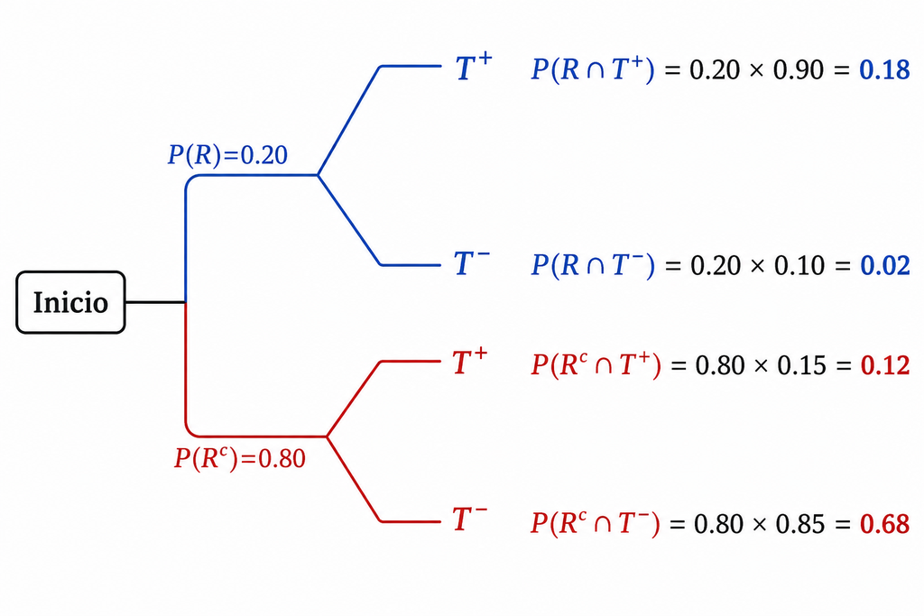

- **$P(T^+)$** = suma de caminos hacia $T^+$ = $0.18 + 0.12 = 0.30$
- Verificación: $0.18 + 0.02 + 0.12 + 0.68 = 1.00$ ✓

## Solución Paso a Paso

Aplicamos el Teorema de Bayes:
$$P(R \mid T^+) = \frac{P(T^+ \mid R)\,P(R)}{P(T^+ \mid R)\,P(R) + P(T^+ \mid R^c)\,P(R^c)}$$

- **Numerador:** $P(T^+ \mid R)\,P(R) = 0.90 \times 0.20 = 0.18$
- **Denominador:** $P(T^+) = 0.18 + 0.80 \times 0.15 = 0.18 + 0.12 = 0.30$
- **Resultado:** $P(R \mid T^+) = \dfrac{0.18}{0.30} = 0.60$
- Dado un resultado positivo, hay un **60% de probabilidad** de que el animal sea realmente resistente.

## Interpretación:

- A pesar de que la prueba tiene **90% de sensibilidad**, un resultado positivo solo indica resistencia con probabilidad **60%**.
- Esto se debe a la **baja prevalencia** (20%): la mayoría de animales no son resistentes, por lo que muchos positivos provienen de falsos positivos.
- Este fenómeno se conoce como la **paradoja de la prevalencia baja**: las pruebas diagnósticas son menos informativas cuando la condición es rara.
- En la práctica zootécnica, conocer la prevalencia regional es tan importante como la calidad del instrumento de medición.

## Efecto de la Prevalencia en el VPP

| Prevalencia $P(R)$ | Num. = $0.90 \times P(R)$ | Den. = Num. + $0.15 \times P(R^c)$ | $P(R \mid T^+)$ |
| --- | --- | --- | --- |
| 5% | 0.0450 | 0.0450 + 0.1425 = 0.1875 | **24.0%** |
| 20% | 0.18 | 0.18 + 0.12 = 0.30 | **60.0%** |
| 50% | 0.450 | 0.450 + 0.075 = 0.525 | **85.7%** |
| 80% | 0.72 | 0.72 + 0.03 = 0.75 | **96.0%** |

**El VPP o valor predictivo positivo es la probabilidad de que ocurra el evento de interés dado que el resultado observado fue positivo.**

## Sensibilidad

$$\text{Sensibilidad} = P(\text{test}^+ \mid \text{enfermo}) = \frac{VP}{VP + FN}$$

- Mide la **capacidad de la prueba para detectar casos verdaderos** (enfermos o afectados).
- $VP$ = Verdaderos Positivos; $FN$ = Falsos Negativos (enfermos no detectados).
- Una prueba con alta sensibilidad tiene pocas **pérdidas de casos reales**, importante cuando el costo de no detectar es alto (p.ej., brotes de enfermedad).

## Especificidad

$$\text{Especificidad} = P(\text{test}^- \mid \text{sano}) = \frac{VN}{VN + FP}$$

- Mide la **capacidad de la prueba para identificar correctamente los sanos** (no afectados).
- $VN$ = Verdaderos Negativos; $FP$ = Falsos Positivos (sanos que dan positivo).
- Una prueba con alta especificidad tiene pocos **falsos positivos**, importante para evitar tratamientos innecesarios costosos.

## VPP y VPN

Valor Predictivo Positivo (VPP)

$$\text{VPP} = P(\text{enfermo} \mid \text{test}^+) = \frac{VP}{VP + FP}$$

- De todos los que dan positivo, ¿qué fracción está realmente enferma?
- Es directamente la **probabilidad a posteriori** calculada con Bayes.

Valor Predictivo Negativo (VPN)

$$\text{VPN} = P(\text{sano} \mid \text{test}^-) = \frac{VN}{VN + FN}$$

- De todos los que dan negativo, ¿qué fracción está realmente sana?
- También se calcula con Bayes: $P(\text{sano} \mid T^-) = \frac{P(T^- \mid \text{sano})\,P(\text{sano})}{P(T^-)}$

## Tabla de Contingencia para prueba diagnóstica

|  | Enfermo ($D^+$) | Sano ($D^-$) | Total |
| --- | --- | --- | --- |
| Test $+$ | VP (Verdadero Positivo) | FP (Falso Positivo) | VP + FP |
| Test $-$ | FN (Falso Negativo) | VN (Verdadero Negativo) | FN + VN |
| Total | VP + FN | FP + VN | $n$ |

- Sensibilidad $= \frac{VP}{VP+FN}$
- Especificidad $= \frac{VN}{VN+FP}$
- VPP $= \frac{VP}{VP+FP}$
- VPN $= \frac{VN}{VN+FN}$

## Relación entre VPP y el Teorema de Bayes

El VPP es exactamente la probabilidad a posteriori de estar enfermo dado un resultado positivo:

$$\text{VPP} = P(D^+ \mid T^+) = \frac{P(T^+ \mid D^+)\,P(D^+)}{P(T^+ \mid D^+)\,P(D^+) + P(T^+ \mid D^-)\,P(D^-)}$$

donde $P(T^+ \mid D^+) = \text{Sensibilidad}$ y $P(T^+ \mid D^-) = 1 - \text{Especificidad}$.

- El VPN es la probabilidad a posteriori de estar sano dado resultado negativo: $P(D^- \mid T^-)$.
- Ambos dependen de la **prevalencia** $P(D^+)$, que actúa como probabilidad a priori.

## Ejemplo 2: enfermedades en hato bovino

En una región del Tolima con hato bovino, la prevalencia de *Aspergillus* (enfermedad) es del **30%**. Se usa una prueba rápida con sensibilidad **88%** y especificidad **80%**. Calcular VPP y VPN.

- Sea $H$ = Animal infectada, $T^+$ = Prueba positiva.
- $P(H) = 0.30$, $P(T^+ \mid H) = 0.88$, $P(T^- \mid H^c) = 0.80 \Rightarrow P(T^+ \mid H^c) = 0.20$.
- **VPP:** $\dfrac{0.88 \times 0.30}{0.88 \times 0.30 + 0.20 \times 0.70} = \dfrac{0.264}{0.264 + 0.140} = \dfrac{0.264}{0.404} \approx 0.653$
- **VPN:** $\dfrac{0.80 \times 0.70}{0.80 \times 0.70 + 0.12 \times 0.30} = \dfrac{0.560}{0.560 + 0.036} = \dfrac{0.560}{0.596} \approx 0.940$

## Interpretación:

VPP = 65.3%

- De cada 100 animales con prueba positiva, aproximadamente **65** están realmente infectadas.
- El 35% restante son **falsos positivos**: animales sanas que arrojaron positivo.
- Recomendación: confirmar con una segunda prueba antes de aplicar tratamiento veterinario.

VPN = 94.0%

- De cada 100 animales con prueba negativa, aproximadamente **94** están realmente sanas.
- Un resultado negativo es muy confiable, ya que pocas animales infectadas pasarán desapercibidas.
- El VPN es alto en parte porque la prevalencia (30%) no es extremadamente alta.

## Generalización a $k$ Hipótesis

Para una partición $\{B_1, B_2, \ldots, B_k\}$ con $k > 2$:
$$P(B_i \mid A) = \frac{P(A \mid B_i)\,P(B_i)}{\displaystyle\sum_{j=1}^{k} P(A \mid B_j)\,P(B_j)}, \quad i = 1, 2, \ldots, k$$

- Las hipótesis pueden representar: **orígenes diferentes** de una muestra, **dietas** de una especie, **regiones** de producción, etc.
- El cálculo es idéntico para cada hipótesis, solo cambia el numerador.
- **Verificación:** $\sum_{i=1}^k P(B_i \mid A) = 1 \rightarrow$ siempre debemos comprobarlo.

## Ejemplo 3: origen del lote de lechones

Un lote de lechones puede provenir de tres proveedores: $B_1$ (Cundinamarca), $B_2$ (Boyacá) y $B_3$ (Nariño). Se selecciona un animal al azar y **sobrevive** (evento $A$). ¿Cuál proveedor es más probable?

| Proveedor | $P(B_i)$ (participación) | $P(A \mid B_i)$ (tasa supervivencia) |
| --- | --- | --- |
| $B_1$ C/marca | 0.50 | 0.80 |
| $B_2$ Boyacá | 0.30 | 0.70 |
| $B_3$ Nariño | 0.20 | 0.60 |

## Solución

#### Animal de probabilidades

- ```
                     ┌─ Sobrevive (A):  0.50 × 0.80 = 0.40
  P(B₁)=0.50 ────────┤
                     └─ No sobrevive:  0.50 × 0.20 = 0.10

                     ┌─ Sobrevive (A):  0.30 × 0.70 = 0.21
  P(B₂)=0.30 ────────┤
                     └─ No sobrevive:  0.30 × 0.30 = 0.09

                     ┌─ Sobrevive (A):  0.20 × 0.60 = 0.12
  P(B₃)=0.20 ────────┤
                     └─ No sobrevive:  0.20 × 0.40 = 0.08
  ```

  **Verificación:**  
  $0.40 + 0.10 + 0.21 + 0.09 + 0.12 + 0.08 = 1.00$

#### Calculando el denominador por ley de Probabilidad Total:

- $$P(A)=\sum_{j=1}^{3} P(A \mid B_j)\,P(B_j)$$
- $P(A \mid B_1)\,P(B_1)=0.80 \times 0.50=0.40$
- $P(A \mid B_2)\,P(B_2)=0.70 \times 0.30=0.21$
- $P(A \mid B_3)\,P(B_3)=0.60 \times 0.20=0.12$
- $\therefore P(A)=0.40+0.21+0.12=\mathbf{0.73}$

## Cálculo de $P(B_i \mid A)$

- $$P(B_1 \mid A) = \frac{0.40}{0.73} \approx 0.5479$$
- $$P(B_2 \mid A) = \frac{0.21}{0.73} \approx 0.2877$$
- $$P(B_3 \mid A) = \frac{0.12}{0.73} \approx 0.1644$$
- **Verificación:** $0.5479 + 0.2877 + 0.1644 = 1.00$

| Proveedor | A priori $P(B_i)$ | Verosimilitud $P(A\|B_i)$ | Producto | A posteriori $P(B_i\|A)$ |
| --- | --- | --- | --- | --- |
| $B_1$ Cundinamarca | 0.50 | 0.80 | 0.40 | 54.79% |
| $B_2$ Boyacá | 0.30 | 0.70 | 0.21 | 28.77% |
| $B_3$ Nariño | 0.20 | 0.60 | 0.12 | 16.44% |
| Total | 1.00 | , | 0.73 | 100.00% |

## Interpretación:

- A priori, el proveedor $B_1$ (Cundinamarca) tenía un **50% de probabilidad** de ser el origen, mientras que $B_3$ (Nariño) solo tenía un **20%**.
- Al observar que el animal **sobrevivió**, las probabilidades se actualizaron: $B_1$ sube a **54,8%**.
- La supervivencia que más peso tiene es a favor de $B_1$ porque tiene la mayor tasa de supervivencia (80%) y la mayor participación (50%).
- **Conclusión práctica:** Dado que el animal sobrevivió, es más probable que provenga de Cundinamarca; la probabilidad de Nariño disminuye ligeramente.

## Ejemplo 4: zonas de granja avícola

Se monitorean cuatro zonas arroceras del Tolima y Meta. Se selecciona aleatoriamente un animal que muestra **síntomas de piricularia** (enfermedad). ¿De qué zona proviene con mayor probabilidad?

| Zona | $P(Z_i)$ | $P(\text{piricularia} \mid Z_i)$ |
| --- | --- | --- |
| $Z_1$ Espinal | 0.35 | 0.12 |
| $Z_2$ Purificación | 0.25 | 0.18 |
| $Z_3$ Villavicencio | 0.25 | 0.22 |
| $Z_4$ Granada | 0.15 | 0.25 |

## Solución

- **Denominador**
- $P(\text{piricularia}) = P(A)= \sum_{j=1}^4 P(A \mid Z_j)\,P(Z_j)$
- Donde:  
  $P(\text{piricularia} \mid Z_1) = 0.12$, $P(\text{piricularia} \mid Z_2) = 0.18$, $P(\text{piricularia} \mid Z_3) = 0.22$, $P(\text{piricularia} \mid Z_4) = 0.25$.
- $P(A)=0.35(0.12)+0.25(0.18)+0.25(0.22)+0.15(0.25)= 0.0420+0.0450+0.0550+0.0375 = 0.1795$
- Por lo tanto:
- $P(Z_1 \mid A) = 0.0420/0.1795 \approx 23.4\%$
- $P(Z_2 \mid A) = 0.0450/0.1795 \approx 25.1\%$
- $P(Z_3 \mid A) = 0.0550/0.1795 \approx 30.6\%$
- $P(Z_4 \mid A) = 0.0375/0.1795 \approx 20.9\%$
- Suma de todas las probabilidades = 100% ✓
- **Conclusión:** Dado que el animal presenta piricularia, la zona más probable es **Villavicencio ($Z_3$)** con ~30.6%, a pesar de que $Z_1$ era la de mayor participación a priori.

## Actualización Bayesiana Secuencial

- El Teorema de Bayes puede aplicarse de forma **iterativa**: la probabilidad a posteriori del primer análisis se convierte en la probabilidad a priori del segundo.
- Principio: **“la posteriori de hoy es la priori de mañana”**.
- Cada nueva observación (prueba, experimento, medición) **refina** la distribución de probabilidad sobre las hipótesis.
- Con suficientes observaciones, las probabilidades a posteriori convergen hacia la hipótesis verdadera, independientemente de la priori inicial.

## Principio fundamental de la actualización secuencial:

$$P_{\text{nueva priori}}(B_i) \leftarrow P(B_i \mid A_1) \quad \Rightarrow \quad P(B_i \mid A_1, A_2) = \frac{P(A_2 \mid B_i)\,P(B_i \mid A_1)}{\sum_j P(A_2 \mid B_j)\,P(B_j \mid A_1)}$$

- Las observaciones $A_1$ y $A_2$ deben ser **condicionalmente independientes** dado cada $B_i$ para que la actualización sea válida.
- En diagnóstico de lotes, dos pruebas realizadas en días distintos sobre la misma animal pueden cumplir este supuesto si los factores ambientales no correlacionan los errores.
- La actualización secuencial es **equivalente** a aplicar Bayes una sola vez con toda la evidencia simultánea.

## Ejemplo 5: dos pruebas en secuencia sobre un lote

En un rebaño caprino en Cundinamarca, se sospecha infección por *Botrytis cinerea* (moho gris). La prevalencia regional es 25%. Se dispone de dos pruebas independientes, cada una con sensibilidad 85% y especificidad 90%. Ambas dan resultado positivo. Calcular la probabilidad de infección.

- **Paso 1**, apriori inicial: $P(I) = 0.25$, $P(T_1^+ \mid I) = 0.85$, $P(T_1^+ \mid I^c) = 0.10$.
- Denominador: $0.85 \times 0.25 + 0.10 \times 0.75 = 0.2125 + 0.0750 = 0.2875$
- **Posteriori 1:** $P(I \mid T_1^+) = 0.2125 / 0.2875 \approx 0.7391$

## Solución

- **Paso 2**, Nueva priori: $P'(I) = 0.7391$ (posteriori del paso 1).
- Nueva denominador: $0.85 \times 0.7391 + 0.10 \times 0.2609 = 0.6282 + 0.0261 = 0.6543$
- **Posteriori 2:** $P(I \mid T_1^+, T_2^+) = 0.6282 / 0.6543 \approx 0.9601$
- **Interpretación:** Después de dos pruebas positivas, la probabilidad de infección sube de 25% a 96%, mostrando el poder acumulativo de la evidencia.
- Resumen: $P(I) = 25\% \xrightarrow{T_1^+} 73.9\% \xrightarrow{T_2^+} 96.0\%$

## Ventaja del Enfoque Bayesiano

Incorporar conocimiento previo

- La probabilidad a priori permite integrar **datos históricos, experimentos anteriores o conocimiento experto** en el análisis.
- En zootecnia: tasas de incidencia históricas de enfermedades, resultados de temporadas anteriores, datos de otras regiones similares.

Aprendizaje continuo

- La actualización secuencial permite **aprender a medida que llegan nuevos datos** sin necesidad de reiniciar el análisis.
- Esto es útil en monitoreo continuo de lotes, ensayos adaptativos y sistemas de alerta temprana.

## Razón de Verosimilitudes

**Forma de cuotas (odds form) del Teorema de Bayes:**
$$\underbrace{\frac{P(B \mid A)}{P(B^c \mid A)}}_{\text{Cuota a posteriori}} = \underbrace{\frac{P(A \mid B)}{P(A \mid B^c)}}_{\text{Razón de verosimilitudes (LR)}} \times \underbrace{\frac{P(B)}{P(B^c)}}_{\text{Cuota a priori}}$$

- La **razón de verosimilitudes (LR)** mide cuánto cambia la cuota de una hipótesis al observar $A$.
- LR $> 1$: la evidencia favorece $B$. LR $= 1$: la evidencia no aporta. LR $< 1$: la evidencia favorece $B^c$.
- Para el ejemplo del ganado: LR $= 0.90 / 0.15 = 6.0\rightarrow$ la prueba es positiva lo que quiere decir que multiplica por 6 las cuotas de que el animal sea resistente.

Aplicaciones

Aplicaciones del teorema de Bayes en el área biologica

## Diagnóstico de enfermedades en lotes

El VPP y el VPN calculados con el Teorema de Bayes orientan la toma de decisiones en campo.

- **Ganado:** mastitis (*Hemileia vastatrix*), antracnosis (*Colletotrichum*): pruebas moleculares o visuales.
- **Aves:** piricularia, pudrición de vaina: la prevalencia varía mucho entre dietas y regiones.
- **Cerdos / Caprinos:** *Phytophthora*, *Botrytis*: baja temperatura aumenta el riesgo, prevalencia mayor en épocas lluviosas.
- El conocimiento de la prevalencia regional es el dato más crítico para el cálculo bayesiano correcto.

## Control de calidad en grupos de animales

- En certificación de lechones, ovinos o bovinos, se muestrea una fracción del lote y se prueba supervivencia o presencia de patógenos.
- El teorema de Bayes permite estimar la probabilidad de que **el lote completo sea de alta calidad** dado el resultado de la muestra.
- Las hipótesis corresponden al **porcentaje de animales defectuosas**: bajo, medio o alto.
- La evidencia es el número de animales defectuosas encontradas en la muestra.
- Las probabilidades a priori pueden fijarse con base en el historial de cada proveedor certificado.

## Estimación de prevalencia de enfermedades por zona climática

- Las enfermedades como el *gusano cogollero* (*Spodoptera frugiperda*) en bovinos tienen prevalencias que varían con la altitud y temperatura.
- Zonas cálidas (< 1000 m.s.n.m.) como el Tolima presentan mayor presión de enfermedad que zonas frías (> 2000 m.s.n.m.) como Nariño.
- Incorporar la zona climática como variable en la probabilidad a priori **mejora sustancialmente** la exactitud diagnóstica.
- Esto se implementa como un modelo bayesiano jerárquico en estudios epidemiológicos pecuarios modernos.

## Selección de tratamientos sanitarios

El razonamiento bayesiano guía la **toma de decisiones bajo incertidumbre**:

- $H_1$ = “el patógeno es enfermedad”.
- $H_2$ = “el patógeno es bacteria”.
- $H_3$ = “el patógeno es virus”.
1. Observamos síntomas en el lote de bovinos (signos clínicos): calculamos $P(H_i \mid \text{síntomas})$.
2. Seleccionamos el tratamiento (tratamiento veterinario, bactericida o control de vectores) que maximiza la probabilidad de éxito dado el diagnóstico más probable.
3. Con nueva evidencia (laboratorio, evolución de síntomas) se actualiza el diagnóstico y se ajusta el tratamiento.

## Ensayos y Experimentos de Campo

Ensayos clínicos (adaptación a biología)

- Los ensayos adaptativos usan la actualización bayesiana para modificar la asignación de tratamientos a medida que se acumulan datos.
- Permite detener el ensayo antes de lo planeado si un tratamiento es claramente superior o inferior.

Experimentos de campo

- Al evaluar dietas para ganado resistentes, la priori puede construirse con datos de experimentos previos en zonas similares.
- Cada temporada de lote aporta nueva evidencia que refina la estimación de la efectividad de la dieta.

## Limitaciones del teorema de Bayes

El teorema es matemáticamente exacto, pero sus resultados son tan buenos como la calidad de los datos de entrada.

- **Sensibilidad y especificidad incorrectas:** si los parámetros de la prueba son imprecisos o corresponden a otra población, el resultado es erróneo.
- **Prevalencia desactualizada:** cambios estacionales o por nuevas dietas de patógeno pueden hacer que la priori sea obsoleta.
- **Partición incompleta:** si no se consideran todas las hipótesis posibles, el denominador es incorrecto.
- **Subjetividad de la priori:** distintos expertos pueden asignar probabilidades a priori diferentes, llevando a conclusiones distintas con los mismos datos.

## Bayes vs Frecuentismo

#### Diferencias Conceptuales

Enfoque Frecuentista

- La probabilidad es la **frecuencia relativa** de un evento a largo plazo en repeticiones del experimento.
- Los parámetros son fijos pero desconocidos (**no tienen distribución de probabilidad**).
- El conocimiento previo no entra formalmente en el análisis estadístico.

Enfoque Bayesiano

- La probabilidad representa **grado de creencia** sobre la veracidad de una hipótesis.
- Los parámetros tienen **distribuciones de probabilidad** que se actualizan con los datos.
- El conocimiento previo se incorpora explícitamente a través de la distribución a priori.

## Fórmulas y conceptos clave

Teorema de Bayes

$$P(B_i|A) = \frac{P(A|B_i)P(B_i)}{\sum_j P(A|B_j)P(B_j)}$$

- $P(B_i)\rightarrow$ a priori
- $P(A|B_i)\rightarrow$ verosimilitud
- $P(B_i|A)\rightarrow$ a posteriori

Diagnóstico y Valores Predictivos

$$\text{VPP} = \frac{\text{Sensib} \times P(D)}{\text{Sensib} \times P(D) + (1-\text{Espec}) \times P(D^c)}$$
$$\text{VPN} = \frac{\text{Espec} \times P(D^c)}{\text{Espec} \times P(D^c) + (1-\text{Sensib}) \times P(D)}$$

- VPP y VPN dependen de la prevalencia
- Actualización secuencial: posteriori → nueva priori

## Esquema General

Ciclo de aprendizaje bayesiano

$\underbrace{P(B_i)}_{\text{Conocimiento previo}} \xrightarrow{\text{Nueva evidencia } A} \underbrace{P(B_i \mid A)}_{\text{Conocimiento actualizado}} \xrightarrow{\text{Nueva evidencia } A'} \underbrace{P(B_i \mid A, A')}_{\text{Conocimiento refinado}} \xrightarrow{\cdots}$

- **Inicio:** definir las hipótesis y asignar probabilidades a priori basadas en conocimiento previo o datos históricos.
- **Observación:** recopilar datos o resultados de pruebas y calcular las verosimilitudes.
- **Actualización:** aplicar el Teorema de Bayes para obtener la distribución a posteriori.
- **Decisión:** usar la distribución a posteriori para tomar decisiones zootécnicas informadas y planificar la siguiente observación.

## Conexión teorema de Bayes con Distribuciones de Probabilidad

**Próximas clases:** Las distribuciones de probabilidad (Bernoulli, Binomial, Poisson, Normal) proporcionan modelos para calcular las verosimilitudes $P(A \mid B_i)$ de forma sistemática.

- **Distribución Binomial:** número de animales enfermas en una muestra, dado que cada animal tiene probabilidad $p$ de estar enferma.
- **Distribución Poisson:** número de parásitos enfermedad por unidad de área en un lote.
- **Distribución Normal:** medidas continuas como productividad por animal, permite calcular verosimilitudes para hipótesis sobre la media del lote.
- En cada caso, el Teorema de Bayes sigue siendo el **puente entre los datos y las conclusiones sobre las hipótesis**.

Reglas de conteo

Permutaciones, Combinaciones y sus aplicaciones

## Motivación: reglas de conteo

Para aplicar la probabilidad clásica $P(A) = \frac{|A|}{|\Omega|}$, necesitamos **contar** el número de resultados posibles. Las reglas de conteo son herramientas sistemáticas para hacer esto sin listar cada elemento.

Tres herramientas fundamentales:

- principio multiplicativo.
- permutaciones.
- combinaciones.

## Principio fundamental del conteo

Regla del producto

Si un experimento tiene **$k$ etapas** con $n_1, n_2, \ldots, n_k$ opciones respectivamente, el número total de resultados posibles es:
$$N = n_1 \times n_2 \times \cdots \times n_k$$

## Ejemplo 6: dieta × alimentación × dieta

Un productor de bovinos debe elegir entre:

- **3 dietas**: V1, V2, V3
- **2 sistemas de alimentación**: goteo, aspersión
- **4 tipos de dieta**: arcilloso, arenoso, franco, limoso

¿Cuántas combinaciones de tratamiento posibles hay?

#### Solución

- $n_1 = 3$, $n_2 = 2$, $n_3 = 4$
- $$N = 3 \times 2 \times 4 = 24 \text{ combinaciones}$$

Cada uno de los 24 tratamientos es un resultado elemental del espacio muestral.

## Diagrama de animal: dieta × alimentación

Animal para 3 dietas × 2 sistemas de alimentación (primeras dos etapas)

- V1 → Goteo → (V1, G)
- V1 → Aspersión → (V1, A)
- V2 → Goteo → (V2, G)
- V2 → Aspersión → (V2, A)
- V3 → Goteo → (V3, G)
- V3 → Aspersión → (V3, A)
- El animal muestra $3 \times 2 = 6$ combinaciones en dos etapas.
- Al agregar la tercera etapa (4 dietas), cada rama se multiplica por 4: $6 \times 4 = 24$.
- Los animales son útiles para visualizar; el principio multiplicativo es más eficiente para contar.

## Permutaciones:

Definición

Una **permutación** es un arreglo **ordenado** de objetos. El **orden importa**: dos arreglos con los mismos elementos en distinto orden son permutaciones diferentes.

Número de permutaciones de $n$ objetos distintos:
$$P_n = n! = n \times (n-1) \times \cdots \times 2 \times 1$$

## Ejemplo 7: ordenar dietas para aves

Un investigador tiene 4 dietas para aves: Dieta A, Dieta B, Dieta C, Dieta D. Desea ordenarlas en una corral de ensayo. ¿De cuántas formas puede hacerlo?

#### Solución

- $n = 4$
- $$P_4 = 4! = 4 \times 3 \times 2 \times 1 = 24 \text{ formas}$$
- Cada orden produce una configuración experimental diferente.

## Permutaciones de $r$ elementos tomados de $n$

Definición

$$P(n, r) = \frac{n!}{(n-r)!}$$

Número de formas de seleccionar y **ordenar** $r$ objetos de un conjunto de $n$ objetos distintos.

## Ejemplo 8: asignación de corrales

Hay 8 corrales disponibles y se deben asignar 3 tratamientos distintos (T1, T2, T3), uno a cada corral, en un orden específico. ¿De cuántas maneras se pueden ordenar?

#### Solución

- $n = 8$, $r = 3$
- $$P(8,3) = \frac{8!}{(8-3)!} = \frac{8!}{5!} = 8 \times 7 \times 6 = 336$$

Hay 336 formas distintas de asignar los 3 tratamientos ordenadamente.

## Permutaciones con repetición

Fórmula

Si se tienen $n$ objetos donde hay $n_1$ iguales del tipo 1, $n_2$ del tipo 2, …, $n_k$ del tipo $k$, con $n_1 + n_2 + \cdots + n_k = n$:
$$P = \frac{n!}{n_1!\, n_2!\, \cdots\, n_k!}$$

## Ejemplo 9: organizar animales en corral

Se tienen 7 animales: 3 Sanas (S), 2 con enfermedad (P) y 2 con deficiencia (D). Si se organizan en una corral. ¿Cuántos arreglos distintos existen?

#### Solución

- $n = 7$, $n_1 = 3$ (S), $n_2 = 2$ (P), $n_3 = 2$ (D)
- $$P = \frac{7!}{3!\,2!\,2!} = \frac{5040}{6 \times 2 \times 2} = \frac{5040}{24} = 210$$

Existen 210 arreglos distintos en la corral.

## Combinaciones:

Definición

Una **combinación** es una selección de $r$ objetos de un conjunto de $n$, donde el **orden NO importa**. Dos selecciones con los mismos elementos en distinto orden son la misma combinación.
$$\binom{n}{r} = \frac{n!}{r!\,(n-r)!}$$

## Ejemplo 10: dietas para bovinos.

Un profesional en zootecnia tiene disponibles 10 dietas para bovinos para un ensayo experimental y necesita escoger 3 dietas para sembrarlas en una corral piloto. ¿Cuántas combinaciones de dietas puede elegir?

#### Solución

- $n = 10$, $r = 3$
- Formula: $\binom{n}{r} = \frac{n!}{r!(n-r)!}$
- Reemplazando: $\frac{10!}{3!(10-3)!} = \frac{10!}{3! \cdot 7!} = \frac{10 \times 9 \times 8}{3 \times 2 \times 1} = 120$

El zootecnista puede formar 120 grupos diferentes de 3 dietas para bovinos.

## Permutaciones vs Combinaciones

#### Permutaciones (orden importa)

- $\{A, B, C\}$ y $\{B, A, C\}$ son **diferentes**.
- Ejemplo: asignar el *primer*, *segundo* y *tercer* lugar en un concurso de dietas.

#### Combinaciones (orden no importa)

- $\{A, B, C\}$ y $\{B, A, C\}$ son **iguales**.
- Ejemplo: elegir 3 dietas de 8 para incluir en un ensayo (sin importar el orden).

Relación: $P(n,r) = \binom{n}{r} \times r!$

## Propiedades del coeficiente binomial

**Propiedad 1:** Hay una sola forma de escoger 0 elementos de un conjunto. También hay una sola forma de escoger todos los elementos.

$\displaystyle\binom{n}{0} = 1$ y $\displaystyle\binom{n}{n} = 1$

**Propiedad 2:**  
Escoger $r$ elementos es equivalente a escoger los $n-r$ elementos que se quedan fuera.

$\displaystyle\binom{n}{r} = \binom{n}{n-r}$

**Propiedad 3:**  
Escoger un solo elemento de un conjunto de n elementos puede hacerse de n maneras.

$$\displaystyle\binom{n}{1} = n$$

#### Identidad de Pascal

El número de formas de escoger $r$ elementos de un conjunto de $n$ elementos es igual a la suma de:

$$\binom{n}{r} = \binom{n-1}{r-1} + \binom{n-1}{r}$$

Sirve para calcular combinaciones sin usar factoriales grandes.

## Combinaciones aplicadas a probabilidad clásica

Cuando los elementos se seleccionan sin orden, usamos combinaciones en el numerador y denominador de:
$$P(A) = \frac{|A|}{|\Omega|}$$
.

**Ejemplo**: De un lote de 10 animales del hato (7 sanas, 3 con enfermedad) al seleccionar 3 al azar. ¿Cuál es la probabilidad de que las 3 sean sanas?

$$P(\text{3 sanas}) = \frac{\binom{7}{3}}{\binom{10}{3}} = \frac{35}{120} \approx 0.292$$

## Ejemplo 11: muestrear aves

Un lote de 20 aves contiene 14 sanas y 6 con enfermedad. Se seleccionan 5 animales al azar para inspección. Calcule:

1. número total de selecciones posibles,
2. $P(\text{exactamente 2 enfermas})$.

#### Solución

- 1. $|\Omega| = \binom{20}{5} = 15504$
- 2. Seleccionar 2 enfermas de 6 y 3 sanas de 14:
     $$|A| = \binom{6}{2} \times \binom{14}{3} = 15 \times 364 = 5460$$
- $$P(A) = \frac{5460}{15504} \approx 0.352$$

## Tabla comparativa: tres enfoques de probabilidad

| Enfoque | Definición | Requiere | Limitación |
| --- | --- | --- | --- |
| **Clásico** | $\|A\|/\|\Omega\|$ | Equiprobabilidad | $\Omega$ finito |
| **Frecuentista** | $\lim f_A/n$ | Repetición | $n \to \infty$ irreal |
| **Axiomático** | 3 axiomas | Consistencia formal | No asigna valores |

## Resumen:

#### Teorema de Bayes

- **Prob. condicional:** $P(A \mid B) = \dfrac{P(A \cap B)}{P(B)}$
- **Prob. total:** $P(B) = \sum_{i} P(B \mid A_i)\,P(A_i)$
- **Fórmula:** $P(A_i \mid B) = \dfrac{P(B \mid A_i)\,P(A_i)}{\sum_j P(B \mid A_j)\,P(A_j)}$
- **Prior** $P(A_i)$ → **Posterior** $P(A_i \mid B)$

#### Reglas de conteo

- **Principio multiplicativo:** $N = n_1 \times n_2 \times \cdots \times n_k$
- **Permutaciones (todo):** $P_n = n!$
- **Permutaciones ($r$ de $n$):** $P(n,r) = \frac{n!}{(n-r)!}$
- **Permutaciones con repetición:** $\frac{n!}{n_1!\cdots n_k!}$
- **Combinaciones:** $\binom{n}{r} = \frac{n!}{r!(n-r)!}$

## Ejemplo: probabilidad con principio multiplicativo

#### Enunciado

- Un investigador crea códigos de identificación para corrales de aves usando: 1 letra (A, B, C) seguida de 2 dígitos (0–9). ¿Cuántos códigos hay? Si elige uno al azar, ¿cuál es la probabilidad de que empiece con B?

#### Solución

- Total: $3 \times 10 \times 10 = 300$ códigos.
- Códigos con B: $1 \times 10 \times 10 = 100$.
- $$P(\text{empieza con B}) = \frac{100}{300} = \frac{1}{3} \approx 0.333$$

## Cuándo usar cada herramienta de conteo

| Situación | ¿Orden importa? | ¿Repetición? | Herramienta |
| --- | --- | --- | --- |
| Ordenar $n$ objetos distintos | Sí | No | $n!$ |
| Elegir y ordenar $r$ de $n$ | Sí | No | $P(n,r)$ |
| Ordenar con grupos repetidos | Sí | Sí | $\frac{n!}{n_1!\cdots n_k!}$ |
| Elegir $r$ de $n$ sin orden | No | No | $\binom{n}{r}$ |
| Etapas independientes | , | , | Principio multiplicativo |

## Ejercicio de repaso Verdadero o Falso

- 1. $P(A) = 1.2$ es un valor de probabilidad válido. **Falso**
- 2. Si $P(A) = 0$, entonces $A = \emptyset$. **Falso**
- 3. $\binom{8}{3} = \binom{8}{5}$. **Verdadero**
- 4. $P(3,2) = \binom{3}{2}$.  
     **Falso** ($P(3,2)=6$ y $\binom{3}{2}=3$)
- 5. Si $A$ y $B$ son disjuntos: $P(A \cup B) = P(A) + P(B)$. **Verdadero**

## Aplicaciones en biología y zootecnia

#### Conteo en investigación pecuario

- Diseño de experimentos: cuántas combinaciones de tratamientos son posibles.
- Muestreo: ¿de cuántas formas puedo tomar una muestra representativa?
- Control de calidad: probabilidad de encontrar defectos en una muestra.

#### Probabilidad en genética vegetal

- Cruzamiento de dietas: contar genotipos posibles.
- Herencia mendeliana: probabilidad de obtener cierto fenotipo.
- Selección de individuos para cruzamiento: combinaciones relevantes.

## Bibliografía sugerida

- Walpole, R. E., Myers, R. H., Myers, S. L. y Ye, K. (2012). *Probabilidad y Estadística para Ingeniería y Ciencias*, 9ª ed. Pearson. Capítulos 2 y 3.
- Devore, J. L. (2016). *Probabilidad y Estadística para Ingeniería y Ciencias*, 9ª ed. Cengage. Capítulo 2.
- Ross, S. M. (2014). *Introducción a la Probabilidad y la Estadística para Ingenieros y Científicos*, 4ª ed. Academic Press. Capítulos 2 y 3.